# Twitteranalyse in R

Marius Saeltzer

17 10 2022

## Social Media Analyse

Mit der zunehmenden Verlagerung sozialer Interaktion in den digitalen Raum enstehen gewaltige Mengen digitaler Spurendaten. Für die Sozialwissenschaften, die bisher von offiziellen Registerdaten und/oder Rückschlüsse auf soziale Prozesse ziehen musste, ist der Zugang zu diesen “gefundendenen” Daten ein großes Potential.

Insbesondere Soziale Medien erlauben einen Einblick in Prozesse, die zuvor kaum beobachtbar waren. Die Probleme mit diesen Quellen sind eher der kaum zu kontrollierende Überfluss als die mangelnde Verfügbarkeit. Aus diesem Grund sind zunehmend Wissenschafter*innen dazu übergegangen, (teil-) automatisierte Verfahren in die eigenen Forschungsprozesse miteinzubeziehen. Entsprechend sehen wir eine zunehmende Diffusion von Methoden der Informatik, und das Schaffen neuer Grenzwissenschaften der Computational Social Science.

## Datensammlung

Der Zugang zu diesen Daten ist somit von zentraler Bedeutung, und wird ebenfalls durch automatisierte Sammlungstechniken ermöglicht. Während zuvor die Digitaliserung der Daten (Inhaltsanalyse, Befragungen) ein zentraler Aspekt der Forschung waren, findet die Sammlung digitaler Spurendaten vor allem in Internetquellen mit Hilfe von Computerprogrammen statt. Hier unterscheiden wir zwei Methoden: das Crawling/Scraping imitiert menschliches Nutzerverhalten und bewegt sich (oft ohne Wissen oder Zustimmung des Anbieters) durch das Netz. Die zweite Methode ist die Nutzung der Datenbanken des Anbieters, meist mit Application Programming Interfaces.

## Was ist eine API?

Application Programming Interfaces (API) sind Programmierschnittstellen für Entwickler, die es erlauben die Datenbanken des Anbieters der API auszulesen. Hierzu werden Befehle mit Abfragen formuliert und durch den Server beantwortet. Je nach Kontext ist dies offen zugänglich, erfordert Anmeldung und Authetifizierung, oder ist nur intern verfügbar. In diesem Tutorial beschäftigen wir uns mit dem sozialen Medium Twitter.

Twitter stellt für Forschung und Unternehmen mehrere API Zugänge zur Verfügung. Die Standard Ausführung ist die Twitter API. Jeder Nutzer mit Twitteraccount kann Zugang beantragen, und bekommt diesen für gewöhnlich auch gewährt. Die Zugänge sind hier limitiert in Bezug auf die Menge und Breite der Daten die zugänglich sind.

Zweitens bietet Twitter zahlenden Kunden eine Reihe von API Zugängen an, die von diesem Restriktionen ausgenommen sind.

Zu guter letzt gibt es für akademische Forschung eine eigene API, die academic API die im Prinzip die gesamte Breite der Daten mit begrenzten Mangen abfragen kann.

## Twitter API in R

Für die standard API und die academic API gibt es sogenannte “Wrapper” in verschiedenen Programmiersprachen. Für Data Science sind insbesondere R und Python beliebt. Diese Wrapper erlauben es Anfragen in der Sprache zu formulieren, in der man bervorzugt programmiert. Die beliebtesten Wrapper für R sind die packages rtweet, streamR und academictwitter.

Da academictwitter eine Universitätstelle vorraussetzt, nutzen wir hier rtweet.

```r
if(!require(stringr)){install.packages("stringr")}
if(!require(rtweet)){install.packages("rtweet")}
if(!require(quanteda)){install.packages("quanteda")}
```

```
## Package version: 3.0.0
## Unicode version: 13.0
## ICU version: 69.1
```

```
## Parallel computing: 12 of 12 threads used.
```

```
## See https://quanteda.io for tutorials and examples.
```

## Authentification

API Requests sind so strukturiert, dass ein Paket aus einer Anfrage und den Authentifizierungsinformationen an das Ziel geschickt wird.

Hierfür verwenden wir einen access Token. Wenn Sie noch nicht über Zugangsdaten verfügen, legen Sie sich einen Twitter Account an, wechseln auf das Programmiererportal und folgen dort den Anweisungen. Am Ende erstellen Sie eine APP, die ihnen eine Reihe von authentifcation Daten erlaubt. Wenn Sie bereits einen Twitter Account haben der vernetzt ist, kann die Authentifzierung auch über ein Brwoser Fenster geschehen.

```r
r2<-read.csv("auth/tokens.csv")
```

Wir definieren eine Funktion die einen Token aus einer csv datei mit tokens erzeugt (bitte adaptieren Sie den code entsprechend ihrer Formatierung.)

```r
tokenize<-function(tokens,i){
  return(create_token(app = as.character(tokens[i,3]),consumer_key = tokens[i,4],consumer_secret = tokens[i,5],access_token = tokens[i,6],access_secret = tokens[i,7],set_renv =F))
}
```

```r
tx<-tokenize(r2,2)
```

Sobald der token nun zur Verfügung steht, können wir ihn Nutzen um Daten herunterzuladen.

## User

Als ersten Schritt suchen wir uns ein paar Ziele, in diesem Fall ein paar prominente SPD Accounts.

Der SPD Bundesvorstand:

```r
l1<-lookup_users("spdde",token = tx)
spd_id<-l1$user_id
```

sowie Karl Lauterbach und Ralf Stegner.

```r
l2<-lookup_users("karl_lauterbach",token = tx)
l3<-lookup_users("ralf_stegner",token = tx)
```

## Follower

Social Media wird erst dadurch sozial, als das es ein soziales Netzwerk ist, welches Menschen verbindet. Diese Verbindungen finden entweder in bilataralen Beziehungen oder hierarchischen Beziehungen (Follower) wieder. Jeder Account hat Follower und folgt anderen Accounts (Friends).

```r
get_followers("spdde",n = 100,token = tx)
```

```
## # A tibble: 100 x 1
##    user_id
##    <chr>
##  1 1585598432642834433
##  2 944783814
##  3 1585582689100484610
##  4 1585583015400542209
##  5 1585577763393740801
##  6 1534872442799284225
##  7 1543219756056059906
##  8 1565263871920992257
##  9 1585561033632092167
## 10 1490014053552558088
## # ... with 90 more rows
```

Da die Listen der Follower sehr lang sind bei diesen Accounts ist es sinnvoller sich die Accounts anzusehen, denen die Accounts folgen. Hier lassen sich interessante Rückschlüsse ziehen.

```r
f1<-get_friends(l1$user_id,token=tx)
f2<-get_friends(l2$user_id,token=tx)
f3<-get_friends(l3$user_id,token=tx)
```

```r
gem<-intersect(f1$user_id,union(f2$user_id,f3$user_id))
length(gem)
```

```
## [1] 521
```

Wir laden deren Profile herunter, um einen Überblick zu erhalten.

```r
com<-lookup_users(gem,token=tx)
```

Und ordnen diese nach ihrer Followerzahl.

```r
com<-com[order(com$followers_count,decreasing = T),]
```

Nun schauen wir uns an, wieviele von diesen Accounts sich selbst als SPD identifizieren.

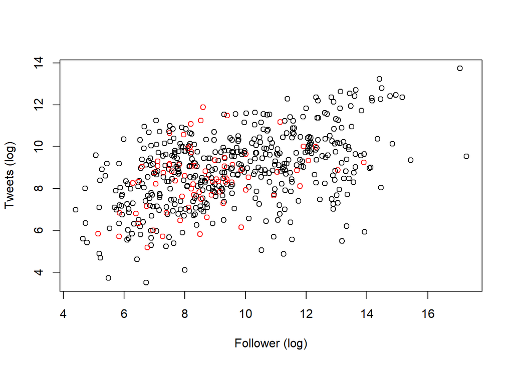

```r
plot(log(com$followers_count),log(com$statuses_count),col=c("black","red")[as.factor(grepl("SPD",com$description))],
     ylab="Tweets (log)",xlab="Follower (log)")
```

```r
mean(grepl("SPD",com$description))
```

```
## [1] 0.1458733
```

Was kann man nun mit diesen Daten anstellen? Zum Beispiel kann man versuchen politische Einstellungen zu schätzen. Wem wir folgen sagt viel über unsere Interessen, unsere Einstellungen und Präferenzen. Pablo Barbera verwendet ein Skalierungsverfahren um Accounts zu gewichten, je nachdem wieviel sie über politische Einstellungen aussagen. Die Logik dahinter ist einfach: wir wollen Nachrichten, die unseren Vorstellungen entsprechen und kognitive Dissonanz vermeiden.

Für diesen Vortrag habe ich die Ideologie anhand einer Reihe von Politikeraccounts berechnet, und Accounts extrahiert, die Aussagen über die Einstellungen der Nutzer erlauben. Hierfür identifizieren wir durch eine Art Faktorenanalyse die “Hauptdimension” der Unterschiede im Followerverhalten.

```r
load("weight_accounts.rdata")

score_lr<-function (friends,w4,user="user")
{
  y <- matrix((w4$user_id %in% friends) * 1,
              nrow = 1)
  if (sum(y) == 0) {
    theta<-NA
    return(theta)
  }
#  message(user, " follows ", sum(y), " elites: ",
#          paste(w4$screen_name[w4$user_id %in%
##                                                 friends], #collapse = ", "))
  theta <- w4$CA1[w4$user_id%in%friends]
  theta <- theta + rnorm(1, 0, 0.05)

  return(mean(theta))
}
```

Diese Funktion berechnet die durchschnittliche Position eines beliebigen Accounts, basierend auf den Friends aus, indem er die Ähnlichkeit im Folge-verhalten mit etwa 800 Politiker*innen vergleicht.

Wir sammeln hierfür die Friends von ein paar prominenten, politischen Accounts, von denen wir einen intutitiven Eindruck haben.

```r
accs<-c("katjakipping",
"alice_weidel",
"ralf_stegner",
"HGMaassen",
"JTrittin",
"ulfposh",
"SWagenknecht",
"stefan_naas_fdp",
"janine_wissler",
"ArminLaschet",
"_FriedrichMerz",
"FESonline",
"KASonline",
"rosaluxstiftung"
)
```

Wir verwandeln diese Objekte in einen Datensatz…

```r
aclist<-list()
```

```r
for(i in 1:length(accs)){
  aclist[[i]]<-get_friends(accs[i],token = tx)
}
```

… und wenden den Algorithmus an.

```r
mx<-lapply(aclist,function(x) score_lr(x$user_id,w4 = w4))
df<-data.frame(name=accs,position=unlist(mx))
```

Werfen wir einen Blick auf politische Einstellungen:

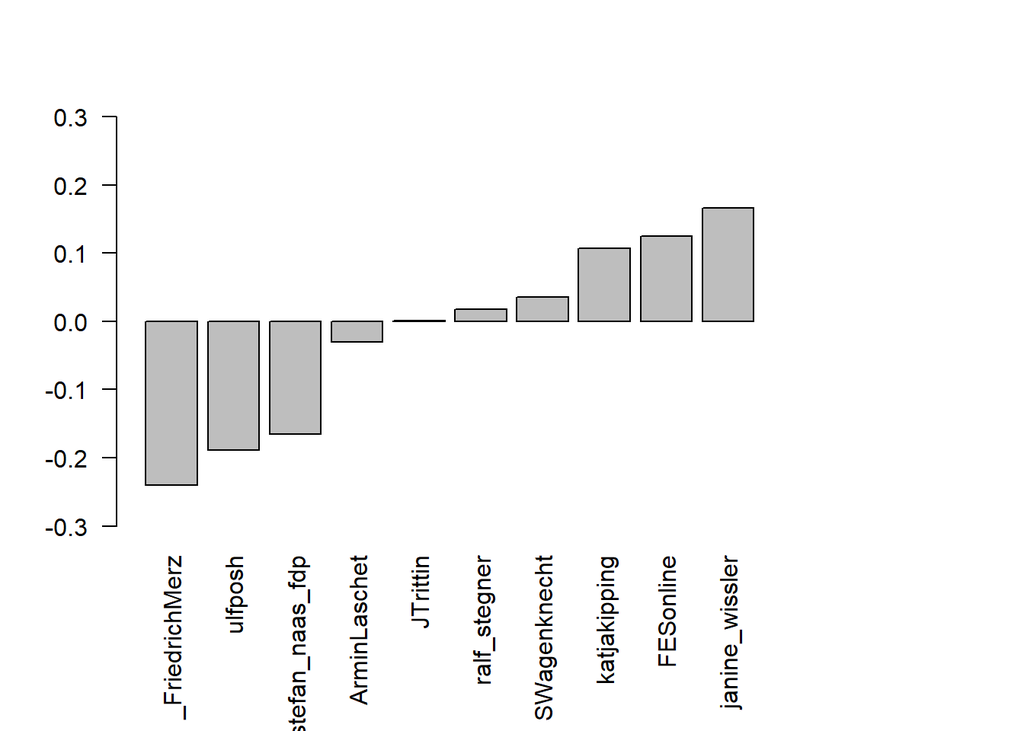

```r
df<-df[order(df$position),]
df1<-df[df$position>(-1),]

par(mar=c(7,4,4,4))
barplot(df1$position,ylim=c(-.3,.3),las=2,names=df1$name,cex.axis = 1)
```

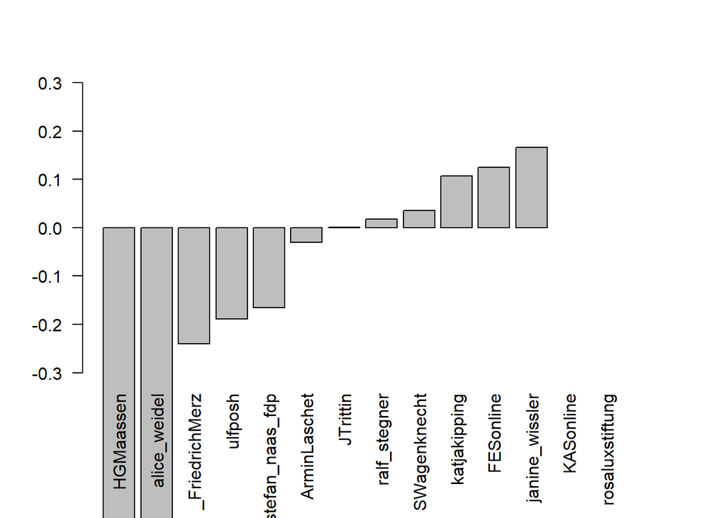

```r
df<-df[order(df$position),]
par(mar=c(7,4,4,4))
barplot(df$position,ylim=c(-.3,.3),las=2,names=df$name,cex.axis = 1)
```

```r
add_friend<-function(acc1,df,w4=w4,tx=tx){
g1<-get_friends(acc1,token = tx)
score_lr(g1$user_id,w4 = w4)
df<-rbind.data.frame(df,data.frame(name=acc1,position=score_lr(g1$user_id,w4 = w4)))
return(df)
}

tx<-tokenize(r2,4)

df2<-add_friend("elhammanea",df,w4=w4,tx=tx)
```

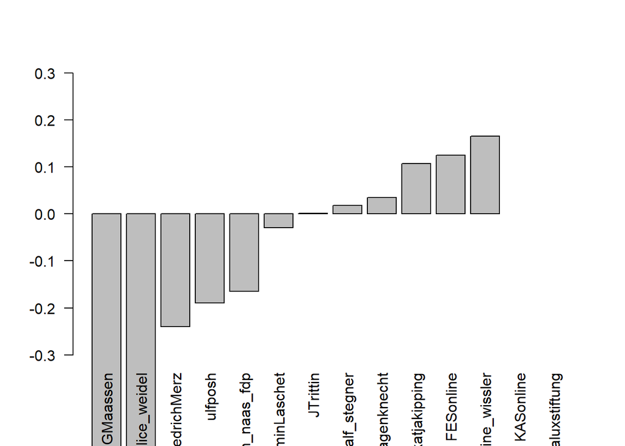

```r
barplot(df$position,ylim=c(-.3,.3),las=2,names=df$name,cex.axis = 1)
```

## Tweetanalyse

Nachdem wir uns die Followernetzwerke angesehen haben werfen wir einen Blick auf die Tweets selbst. Der get_timeline Befehl erlaubt es uns alle Posts einer Liste von Accounts zu sammeln (bis zu 3200 pro account), der search_tweets Befehl einen Keyword-basierten Querschnitt.

Wir komzentieren uns hier auf die gezielte Account Suche.

```r
tweets<-get_timeline(c(l1$user_id,l2$user_id,l3$user_id),token=tx,n=3200)
```

Zunächst prüfen wir schnell, ob die Daten gut aussehen: wie wir sehen haben wir etwa 3200 posts pro Account erhalten, was dem Limit der API entspricht.

```r
table(tweets$screen_name)
```

```
##
## Karl_Lauterbach    Ralf_Stegner           spdde
##            3199            3198            3178
```

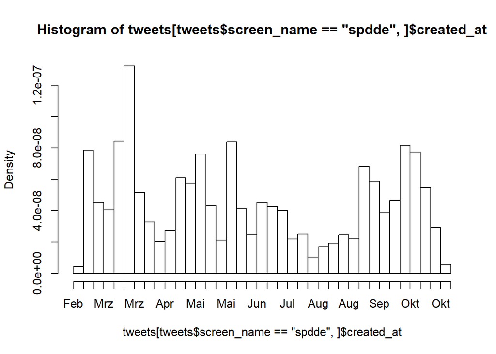

```r
hist(tweets[tweets$screen_name=="spdde",]$created_at,breaks="weeks")
```

Da die SPD relativ viel posted, kommen wir nur bis zum Anfang des Jahres zurück, während wir mit Lauterbach bis ins Jahr 2021 zurück kommen. Falls wir uns allerdings für die Bundestagswahl interessieren, bekommen wir die Daten nicht mehr.

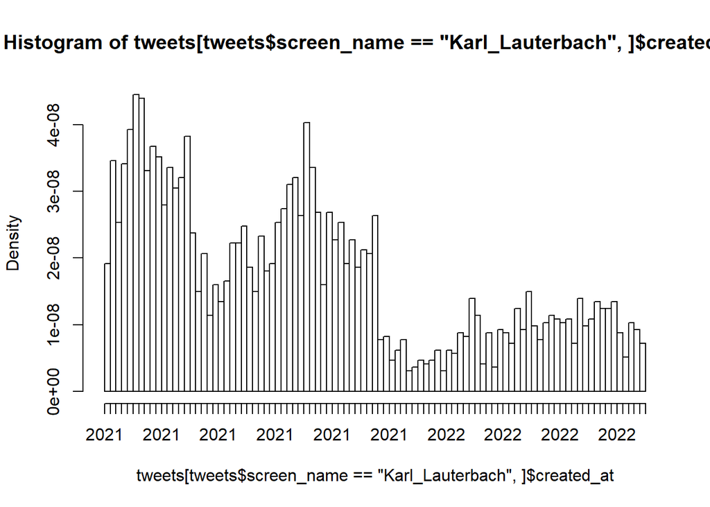

```r
hist(tweets[tweets$screen_name=="Karl_Lauterbach",]$created_at,breaks="weeks")
```

Wieviele dieser Tweets sind nur original content?

```r
table(tweets$is_retweet,tweets$screen_name)
```

```
##
##         Karl_Lauterbach Ralf_Stegner spdde
##   FALSE            3116         1812   809
##   TRUE               83         1386  2369
```

Wieviele Tweets wurden nun von mehreren dieser 3 Accounts geposted?

```r
sum(duplicated(tweets$text))
```

```
## [1] 141
```

# Device

```r
table(tweets$source,tweets$screen_name)
```

```
##
##                        Karl_Lauterbach Ralf_Stegner spdde
##   TweetDeck                          0           58   711
##   Twitter for iPad                  29         3023     0
##   Twitter for iPhone              3170          116  1429
##   Twitter Media Studio               0            0     9
##   Twitter Web App                    0            1  1029
```

```r
spd<-tweets[tweets$screen_name=="spdde",]
```

Wir transformieren die Zeit und schauen uns nur die Stunden des Tages an, an denen im letzten Jahr getwittert wurde.

```r
library(stringr)
hours<-stringr::str_extract(as.character(spd$created_at),"[0-9][0-9]\\:[0-9][0-9]\\:[0-9][0-9]")
time<-as.POSIXct(hours,format="%H:%M:%S")
```

Und nun vergleichen wir die Arbeit mit der Desktop App und dem Iphone:

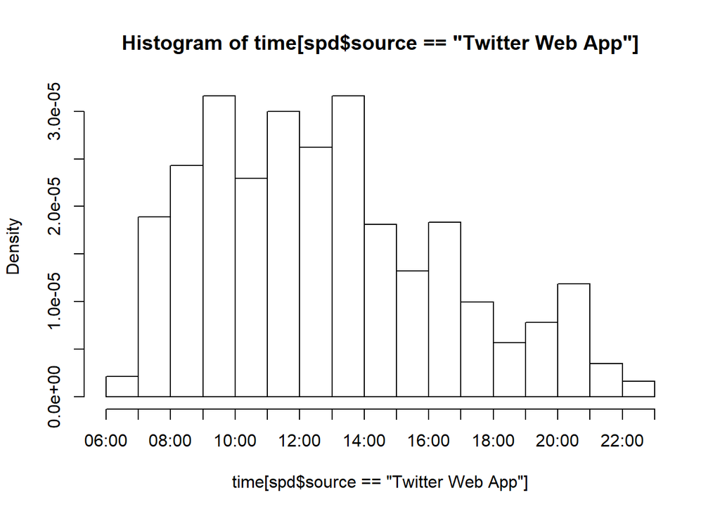

```r
hist(time[spd$source=="Twitter Web App"],breaks="hours")
```

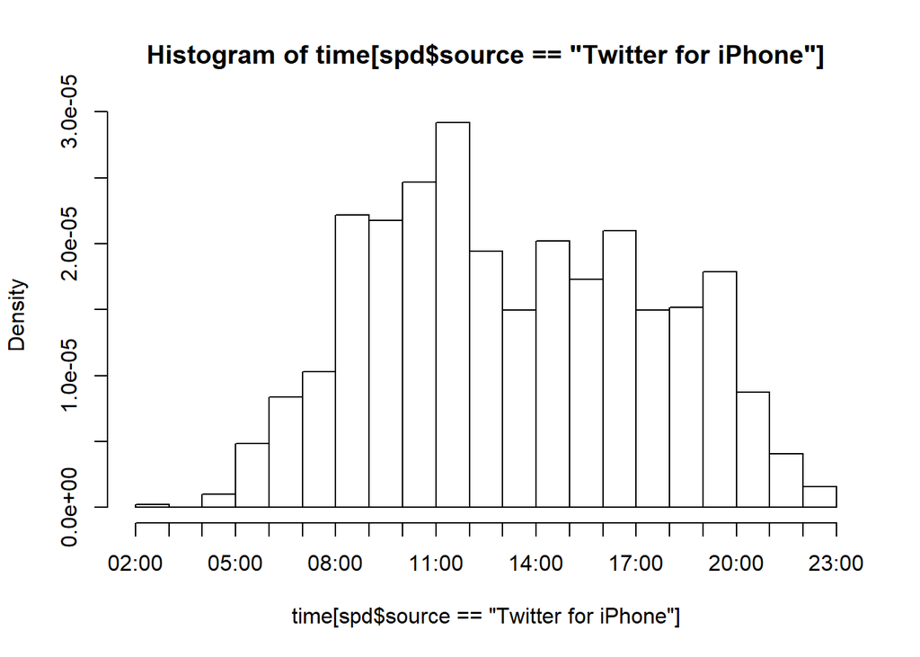

```r
hist(time[spd$source=="Twitter for iPhone"],breaks="hours")
```

### Textanalyse

Zu guter Letzt wollen wir einen Blick in die INHALTE der Tweets werfen: hierfür verwenden wir die Textanalyse Software quanteda, die uns schnelle und effiziente Verdatung von Sprache erlaubt.

Um Worte effizient auswerten zu können erzeugen wir eine sogenannte Document-Feature Matrix (DFM), die uns für jedes im Corpus (hier alle Tweets) angibt, wie oft es in welchem Dokument vorkommt.

Wir überprüfen, in welcher Sprache die Accounts posten:

```r
table(tweets$lang)
```

```
##
##  art   ca   cy   da   de   en   es   et   fr   hu   in   it   iw   nl   no   pl
##   26    1    1    4 8573  667    2    1    6    1    1    1    1    2    2    6
##  qht  qme  qst   ro   sl   sv   tr  und  zxx
##    1    5    1    6    1    2    1   39  224
```

```r
tweets<-tweets[tweets$lang=="de",]
```

Wir beschränken unsere Analyse auf deutsche Tweets.

```r
d1<-dfm(tokens(corpus(tweets$text,docvars=tweets[,c("screen_name","created_at","lang")]),remove_punct=T,remove_numbers=T,remove_symbols=T,remove_url=T))
```

Wir entfernen Zahlen, Satzzeichen und URL.

```r
d1
```

```
## Document-feature matrix of: 8,573 documents, 25,999 features (99.89% sparse) and 3 docvars.
##        features
## docs    mach mit misch dich ein und entwickele uns sozialdemokratische konzepte
##   text1    1   2     1    2   1   3          1   2                   1        1
##   text2    0   0     0    0   0   3          0   0                   0        0
##   text3    0   1     0    0   0   3          0   0                   0        0
##   text4    0   0     0    0   0   2          0   0                   0        0
##   text5    0   0     0    0   0   0          0   0                   0        0
##   text6    0   0     0    0   1   0          0   0                   0        0
## [ reached max_ndoc ... 8,567 more documents, reached max_nfeat ... 25,989 more features ]
```

Insgesamt verwenden diese 3 Accounts 26,000 einzigartige Worte.

```r
topfeatures(d1)
```

```
##  die  der  und   in  ist  das  für  wir   zu  mit
## 7754 6408 6163 4395 3681 3297 3243 2779 2536 2406
```

```r
d1<-dfm_select(d1,pattern = c("dass",stopwords("de")),selection = "remove")
```

```r
topfeatures(d1)
```

```
##          heute           mehr       menschen        impfung         müssen
##            949            736            611            604            519
##          viele          covid           geht    deutschland @bundeskanzler
##            512            477            423            422            404
```

```r
d2<-dfm_select(d1,"#*",selection = "keep")
```

```r
topfeatures(d2)
```

```
##          #ukraine        #longcovid        #bundestag      #mindestlohn
##               270               175               127               122
##              #spd     #nrwvonmorgen     #besseristdas #entlastungspaket
##               102                97                85                82
##          #tvduell           #scholz
##                79                69
```

Und @Mentions

```r
d2<-dfm_select(d1,"@*",selection = "keep")
```

```r
topfeatures(d2)
```

```
##   @bundeskanzler         @youtube      @olafscholz           @spdde
##              404              298              267              217
##   @ankerehlinger   @larsklingbeil @thomaskutschaty   @hubertus_heil
##              189              150              117              115
## @t_losse_mueller  @_friedrichmerz
##              104               91
```

Was wir hier sehen ist nur ein erster Blick auf Textanalyse, sozusagen die erste Aufbereitung dieser Daten für die weitergehende Verarbeitung. Von hier sind Analysen mithilfe maschinellen Lernens auch für große Textscorpora möglich.

Beispiele sind thematische Clusterung, Identifizierung von “Angriffen”, Frames oder auch Hate Speech. Auch die obige Analyse zu politischen Positionen lassen sich mit Textanalyse erstaunlich gut replizieren.

```r
library(ggplot2)
exp<-read.csv("individual.csv")


cols2<-c(
"#b3c6ff",
"#ceccca",
"#aacfee",
"#efc2d8",
"#fff899",
"#bee8b0",
"#ffb3b8")

colors<-c(
  "#0033cc",
"#32302E",
"#87bbe6",
"#bd3075",
"#FFED00",
"#46962B",
"#E3000F")


pcols<-colors

exp$party<-toupper(exp$party)
exp$party<-ifelse(exp$party=="AFD","AfD",exp$party)

nom<-c("Sahra_Wagenknecht","Joachim-Friedrich Martin Josef_Merz","Hans-Georg_Maaßen","Alice Elisabeth_Weidel","Tino_Chrupalla","Janine Natalie_Wißler","Dietmar Gerhard_Bartsch","Christian Wolfgang_Lindner","Olaf_Scholz","Armin_Laschet","Annalena Charlotte Alma_Baerbock")
shortname<-c("Sahra Wagenknecht","Friedrich Merz","Hans-Georg Maaßen","Alice Weidel","Tino Chrupalla","Janine Wißler","Dietmar Bartsch","Christian Lindner","Olaf Scholz","Armin Laschet","Annalena Baerbock")
posi<-c(4,4,4,3,4,1,3,1,2,2,2)
#posi<-c(1,1,1,1,1,1,1,1,1,1)
```

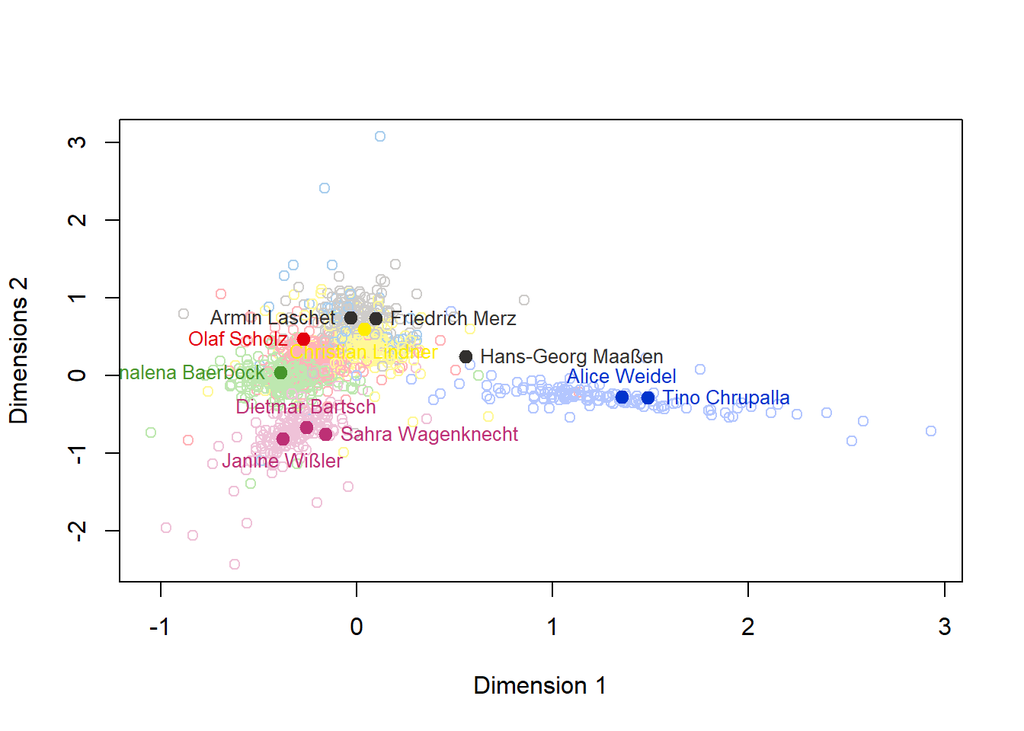

```r
ms2<-exp
ms2$party<-as.factor(ms2$party)
pcols3<-pcols
plot(ms2$score,ms2$score2,col=cols2[as.factor(ms2$party)],cex=1,xlab = "Dimension 1",ylab="Dimensions 2",pch=1)

for(i in 1:length(nom)){
  points(ms2[ms2$fullname==nom[i],]$score,ms2[ms2$fullname==nom[i],]$score2,col=pcols3[ms2[ms2$fullname==nom[i],]$party],pch=19,cex=1.2)
  text(ms2[ms2$fullname==nom[i],]$score,ms2[ms2$fullname==nom[i],]$score2,labels = shortname[i],pos = posi[i],col=pcols3[ms2[ms2$fullname==nom[i],]$party],cex = 0.8)
}
```